# Bellabeat Case Study

Matteo Lotito

2024-02-17

# Research question

Bellabeat is a manufacturer of high-tech health-focused products for women.

Bellabeat wants to become a bigger player in the smart device market In order to do so, we analyze fitness data from a competitor’s smart device.

- Understanding how people use their smart device will help Bellabeat to develop a marketing strategy for their own products.

Specifically we want to ask:

1. Can we identify trends in smart device usage?
2. How do these trends apply to Bellabeat’s customers?
3. How would these trends direct the marketing campaign? .

### Data Sources and References

The data we use for the analysis consists of the FitBit Fitness Tracker data set available at https://www.kaggle.com/datasets/arashnic/fitbit. This is a collection of several CSV files tracking various metrics: daily steps, calories, activity and weight logs. Some data is provided as daily, hourly and minute measurements. For this high level analysis we consider only the daily measurements for steps, sleep, calories, activities and heart rate.

Another reference used is the PDF presentation “Case-Study-2.pdf” sketching the problem and providing a roadmap for the analysis.

## Preparing the data and the analysis tools

We start by loading the raw data.

```r
steps = read.csv("Data/dailySteps_merged.csv")
sleep =  read.csv("Data/sleepDay_merged.csv")
intensity =  read.csv("Data/dailyIntensities_merged.csv")
calories =  read.csv("Data/dailyCalories_merged.csv")
heart = read.csv("data/heartrate_seconds_merged.csv")
weight =  read.csv("Data/weightLogInfo_merged.csv")
```

This comes in various CSV files with several measurements for each user (Id) and over different time periods.

```r
print(steps[30:40, ])
```

```
##            Id ActivityDay StepTotal
## 30 1503960366   5/11/2016     12770
## 31 1503960366   5/12/2016         0
## 32 1624580081   4/12/2016      8163
## 33 1624580081   4/13/2016      7007
## 34 1624580081   4/14/2016      9107
## 35 1624580081   4/15/2016      1510
## 36 1624580081   4/16/2016      5370
## 37 1624580081   4/17/2016      6175
## 38 1624580081   4/18/2016     10536
## 39 1624580081   4/19/2016      2916
## 40 1624580081   4/20/2016      4974
```

Since we are interested in overall metrics and distributions for our population we have to prepare the data accordingly.

After loading the necessary libraries

```r
library(tidyverse)
library(dplyr)
```

we can start transforming the data. The main task is to group by Id, since we don’t want to extract the information for a single user, as that will not be significant.

> We are interested in our overall market opportunities. Once we have the user data instead, such an analysis, per user, would be useful to alert of any unusual > metric or combination thereof. This could be an excellent observation in terms of the health or fitness > condition of the user.

Grouping by user ID and then taking averages (or other statistical metrics when appropriate) we obtain data that we can use for our analysis.

```r
groupedSteps = steps %>% group_by(Id) %>% summarize(Avg = mean(StepTotal))
groupedSleep = sleep %>% group_by(Id) %>% summarize(AvgSleepTime = mean(TotalMinutesAsleep), TimeInBed = mean(TotalTimeInBed))
groupedSleep$SleepTime_H = groupedSleep$AvgSleepTime / 60.
groupedIntensity = intensity %>% group_by(Id) %>% summarize(SM = mean(SedentaryMinutes), LAM = mean(LightlyActiveMinutes), FAM = mean(FairlyActiveMinutes), VAM = mean(VeryActiveMinutes))
groupedCalories = calories %>% group_by(Id) %>% summarize(Cals = mean(Calories))
restingHR = heart %>% group_by(Id) %>% summarize(MinValue = min(Value))
groupedWeight = weight %>% group_by(Id) %>% summarize(BodyMassIndex = mean(BMI))
```

All the data is very clean, there are no missing vakyes in the entries of each metric.

Most of the metrics that we averaged over are in a range of a one month. For this reason, we can average metrics such as the weight and resting heart rate, that would otherwise show interesting, especially if matched with the history of the user using a smart device.

For the heart rate, a useful metric that we calculate for each Id is the resting heart rate, as the minimum over the samepled data. This is a measure of the overall fitness of each individual.

The weight data is provided in both kilogras and pounds, however since we don’t have additional information about the user (height), we retain from the data only the estimated Body Mass Index, calculated by the app (with presumably information about the height of the user).

None of the data contains information on the gender of the sample. We will use averages from the sample, even though this may not show systematic difference between male and female, which would be useful for our analysis.

Overall it seems consistent to use averages for our data since we are interested in understanding who is the typical user of a smart device, therefore useful for our marketing question, rather than focusing on specific trends for each individual.

## Preliminary Analysis

We provide some perliminary graphs to show the distribution of the data in the different categories.

The average steo count is given in the following histogram.

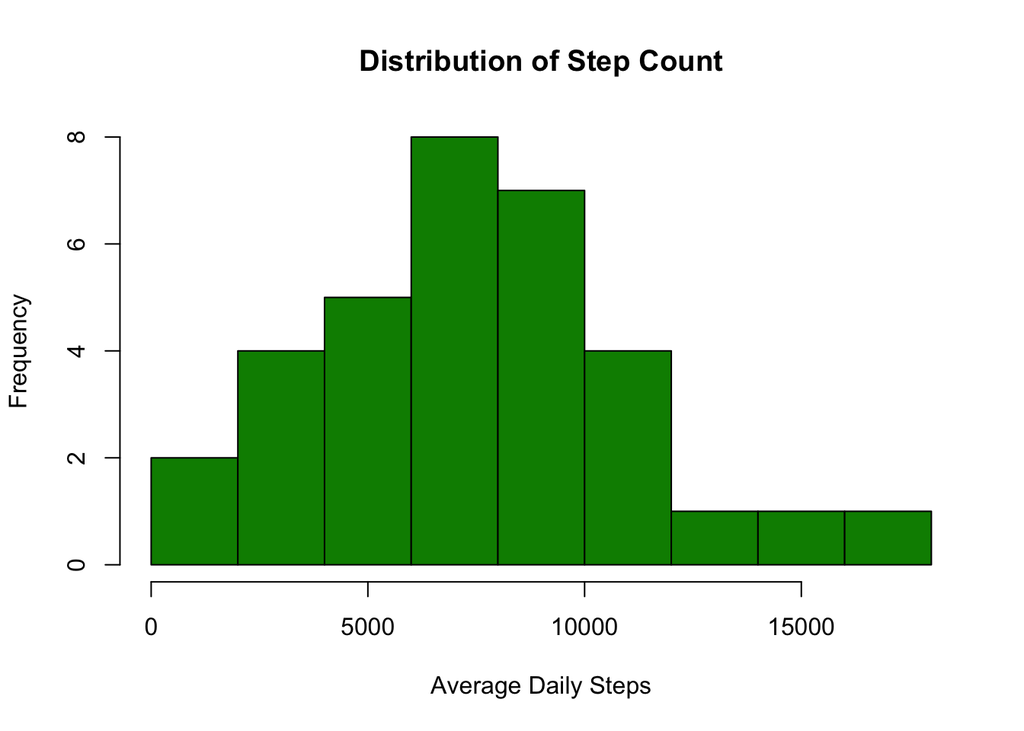

This shows that the typical average step count per person is between 6000 and 8000, which is in line with general recommendations.

> A possible marketing scheme would be to encourage people in the lower bins to use a fitness tracker more.

Next, the average sleep time (in hours), where we measure the actual time asleep, rather than. the total time spent in bed, since this has larger fluctuations.

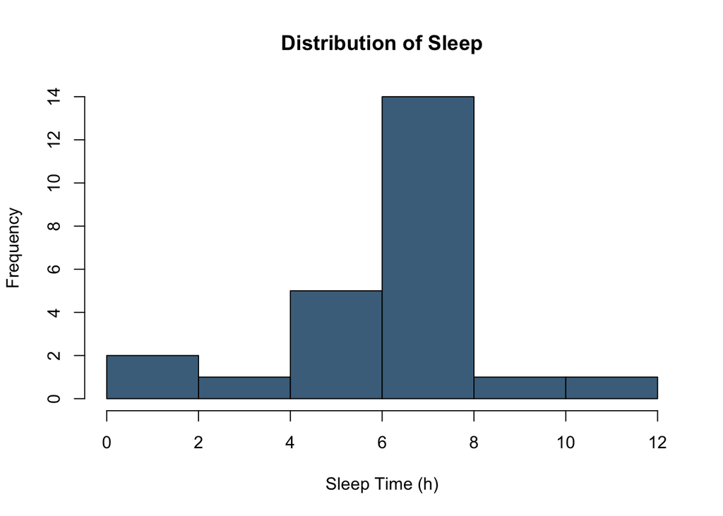

The resting heart rate distribution is below.

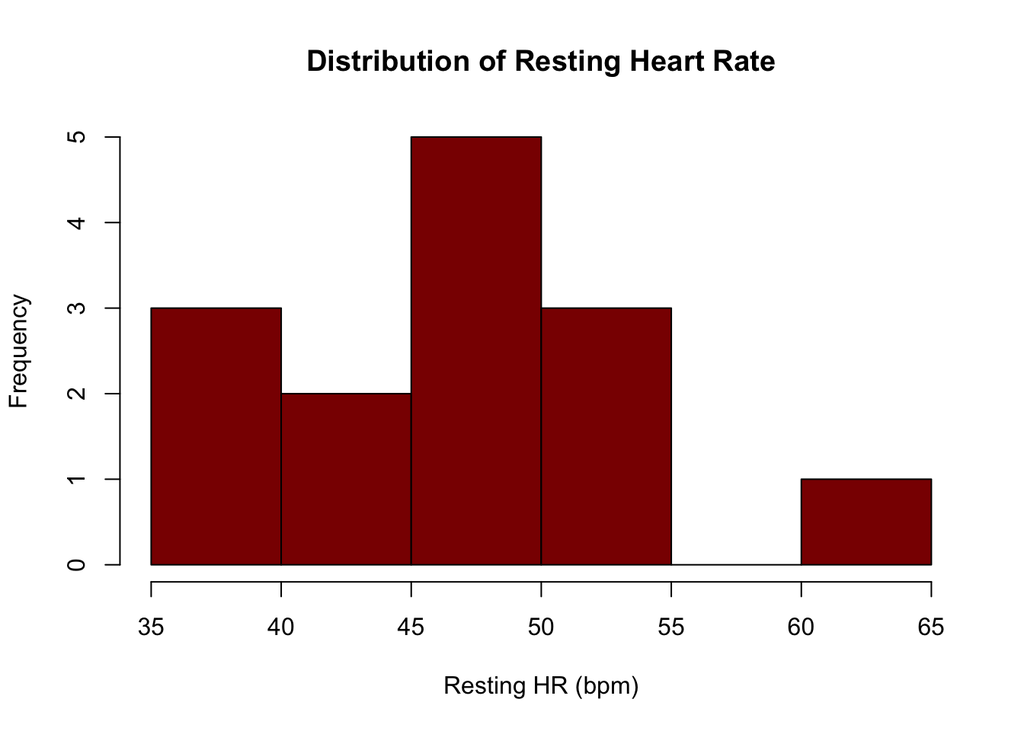

This shows a distribution peaked around very low value, most populated bin 45-50 bpm. Since the average is around 60, it seems likely that most fitness trackers users are individuals who train consistently

> Therefore ew would want to market our product to fitness enthusiasts.

Then we have the distribution of BMI

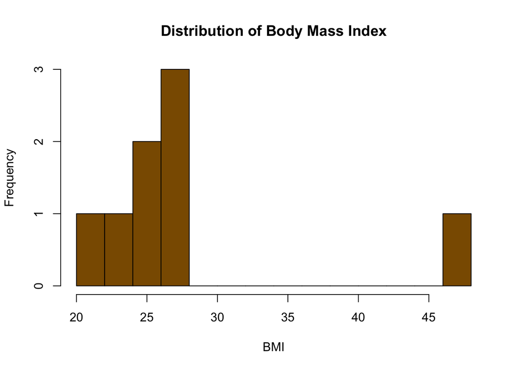

# Findings

From the analysis, we discover that our typical smart device user (averaging over the above metrics) has the following characteristics:

| Attribute | Value |
| --- | --- |
| Steps | 7519.00 |
| Sleep | 6.30 |
| Resting HR | 47.10 |
| BMI | 27.99 |

From the results, we gather that population of smart device users is fairly active, with an average daily step count around the recommendations and about average sleep patterns. The most striking feature is the low resting heart rate. This indicates a high level of cardio / endurance activity. On the other hand, the value of BMI is higher than what is considered usually the healthy range. This may indicate a higher level of muscle tissue (for some users there was informaiton about the body far percentage, howecer it was scarce so I have decided to drop this data altogether). All the data was averaged in an agnostic manner, without caring if the same user had data available fir tgevarious metrics. This is of course only provides a coarse analysis

### Recommnedation

The analysis suggests a typical population of individulas who dedicate time and effort to both cardio / endurance efforts, as well as muscle building.

There is no additional information on the demographics of the sample, data that would be useful to maximize our results would be specifics on age and gender, that woudl be particuklarly valuable for Bellabeat’s position in the marketplace.

In the absence of this additional data, the typical user of smart devides who would fit in Bellabeat’s potential customers is a fitness conscious individual spending time both in cardio and lifting - so this population should be the prime focus of the marketing campaign.